# Tallo — Global Tree Allometry and Crown Architecture Database

plant_scaling_data project

2026-05-02

# 1 Overview

> Jucker T, Fischer FO, Chave J, Coomes DA, Caspersen J, et al. (2022) Tallo: A global tree allometry and crown architecture database. *Global Change Biology*, 28: 5254–5268. DOI: 10.1111/gcb.16302

> Data: Zenodo [doi:10.5281/zenodo.6637599](https://doi.org/10.5281/zenodo.6637599)

> **⚠ Citation note:** The DOI and journal reference above should be verified against Crossref before use in any manuscript.

# 2 Top-level summary

```r
kable(data.frame(
  Metric = c("Total records","Records with stem diameter","Records with height",
             "Records with crown radius","Records with all three",
             "Unique species","Unique genera","Unique families",
             "Unique sites (approx.)", "Lat/lon coverage",
             "Lat range (°)","Lon range (°)","Source studies"),
  Value = c(
    format(nrow(tallo), big.mark=","),
    format(sum(!is.na(tallo$stem_diameter_cm)), big.mark=","),
    format(sum(!is.na(tallo$height_m)),         big.mark=","),
    format(sum(!is.na(tallo$crown_radius_m)),   big.mark=","),
    format(sum(!is.na(tallo$stem_diameter_cm) & !is.na(tallo$height_m) &
               !is.na(tallo$crown_radius_m)),  big.mark=","),
    format(length(unique(tallo$species[!is.na(tallo$species)])), big.mark=","),
    format(length(unique(tallo$genus[!is.na(tallo$genus)])),     big.mark=","),
    format(length(unique(tallo$family[!is.na(tallo$family)])),   big.mark=","),
    "61,856 (per Jucker et al. 2022)",
    paste0(sum(!is.na(tallo$latitude) & !is.na(tallo$longitude)),
           " (100%)"),
    paste0(round(min(tallo$latitude),1), " to ", round(max(tallo$latitude),1)),
    paste0(round(min(tallo$longitude),1), " to ", round(max(tallo$longitude),1)),
    format(length(unique(tallo$reference_id)), big.mark=",")
  )
), caption = "Tallo database top-level summary")
```

Tallo database top-level summary

| Metric | Value |
| --- | --- |
| Total records | 498,838 |
| Records with stem diameter | 498,838 |
| Records with height | 497,335 |
| Records with crown radius | 312,829 |
| Records with all three | 311,326 |
| Unique species | 5,162 |
| Unique genera | 1,453 |
| Unique families | 187 |
| Unique sites (approx.) | 61,856 (per Jucker et al. 2022) |
| Lat/lon coverage | 498838 (100%) |
| Lat range (°) | -51.6 to 69.9 |
| Lon range (°) | -155.3 to 177 |
| Source studies | 69 |

# 3 Column dictionary

```r
kable(meta, caption = "Tallo column descriptions (from Tallo_metadata.csv)")
```

Tallo column descriptions (from Tallo_metadata.csv)

| Field | Description |
| --- | --- |
| tree_id | Unique tree identifier code |
| division | Major phylogenetic division (Angiosperm or Gymnosperm) |
| family | Family name |
| genus | Genus name |
| species | Species binomial name |
| latitude | Latitude (in decimal degrees) |
| longitude | Longitude (in decimal degrees) |
| stem_diameter_cm | Stem diameter (in cm). For multi-stemmed trees values for individual stems (Di) were pooled into a single value calculated as: sqrt(sum(Di^2)) |
| height_m | Tree height (in m) |
| crown_radius_m | Crown radius (in m) |
| height_outlier | Identifier for trees with height values flagged as outliers (Y = outlier; N = non-outlier) |
| crown_radius_outlier | Identifier for trees with crown radius values flagged as outliers (Y = outlier; N = non-outlier) |
| reference_id | Reference code corresponding to the data source from which a record was obtained (see ‘Reference_look_up_table.csv’ for details on data sources). |

# 4 Data availability

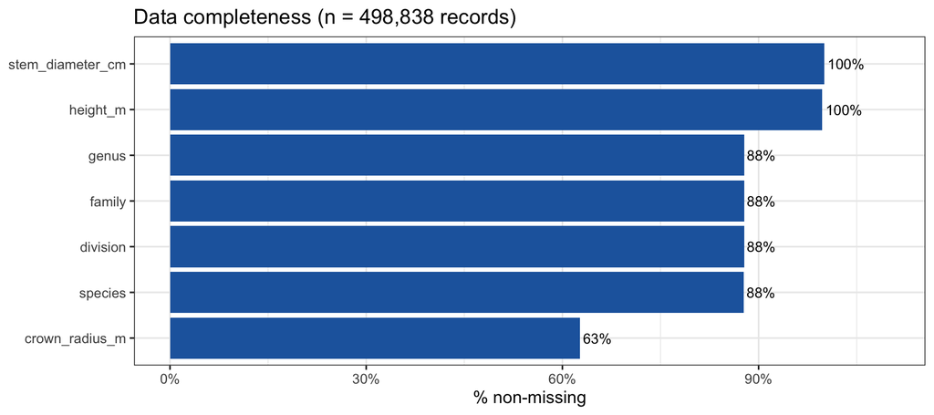

```r
avail <- data.frame(
  variable = c("stem_diameter_cm","height_m","crown_radius_m",
               "species","genus","family","division"),
  n_present = c(
    sum(!is.na(tallo$stem_diameter_cm)),
    sum(!is.na(tallo$height_m)),
    sum(!is.na(tallo$crown_radius_m)),
    sum(!is.na(tallo$species)),
    sum(!is.na(tallo$genus)),
    sum(!is.na(tallo$family)),
    sum(!is.na(tallo$division))
  ),
  total = nrow(tallo)
) |> mutate(pct = n_present / total * 100)

ggplot(avail, aes(x = reorder(variable, pct), y = pct)) +
  geom_col(fill = "#2166ac") +
  geom_text(aes(label = paste0(round(pct), "%")), hjust = -0.1, size = 3.5) +
  coord_flip() +
  scale_y_continuous(limits = c(0, 110), labels = function(x) paste0(x, "%")) +
  labs(x = NULL, y = "% non-missing",
       title = paste0("Data completeness (n = ", format(nrow(tallo), big.mark=","), " records)"))
```

# 5 Global geographic coverage

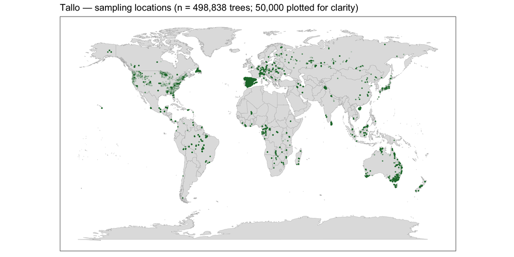

```r
# Thin to ~50k points for fast plotting
set.seed(42)
tallo_thin <- tallo |>
  filter(!is.na(latitude), !is.na(longitude)) |>
  sample_n(min(50000, n()))

world_map <- map_data("world")

ggplot() +
  geom_polygon(data = world_map,
               aes(x = long, y = lat, group = group),
               fill = "grey88", color = "grey70", linewidth = 0.15) +
  geom_point(data = tallo_thin,
             aes(x = longitude, y = latitude),
             alpha = 0.15, size = 0.4, color = "#1b7837") +
  coord_fixed(1.3) +
  labs(title = paste0("Tallo — sampling locations (n = ",
                      format(nrow(tallo), big.mark=","),
                      " trees; 50,000 plotted for clarity)"),
       x = NULL, y = NULL) +
  theme(axis.text = element_blank(),
        axis.ticks = element_blank(),
        panel.grid = element_blank())
```

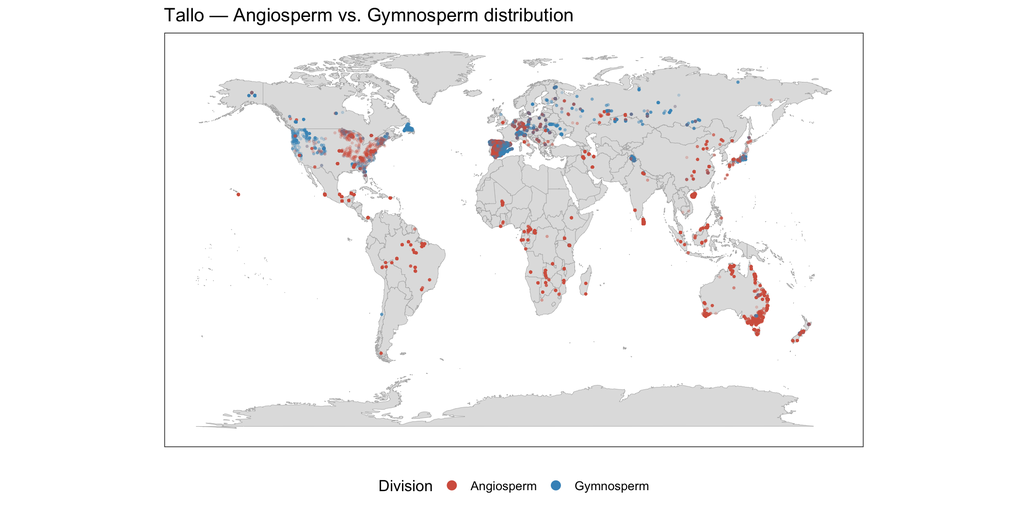

```r
tallo_div <- tallo |>
  filter(!is.na(latitude), !is.na(longitude), !is.na(division)) |>
  sample_n(min(50000, n()))

ggplot() +
  geom_polygon(data = world_map,
               aes(x = long, y = lat, group = group),
               fill = "grey88", color = "grey70", linewidth = 0.15) +
  geom_point(data = tallo_div,
             aes(x = longitude, y = latitude, color = division),
             alpha = 0.2, size = 0.5) +
  scale_color_manual(values = c(Angiosperm = "#d6604d", Gymnosperm = "#4393c3"),
                     na.value = "grey50") +
  coord_fixed(1.3) +
  guides(color = guide_legend(override.aes = list(alpha=1, size=3))) +
  labs(title = "Tallo — Angiosperm vs. Gymnosperm distribution",
       color = "Division", x = NULL, y = NULL) +
  theme(axis.text = element_blank(),
        axis.ticks = element_blank(),
        panel.grid = element_blank(),
        legend.position = "bottom")
```

# 6 Taxonomic coverage

## 6.1 Division breakdown

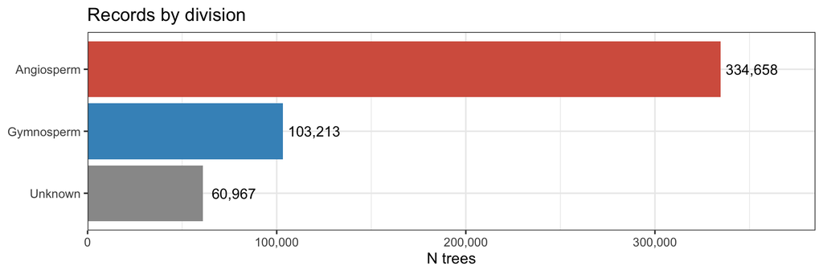

```r
tallo |>
  mutate(division = ifelse(is.na(division), "Unknown", division)) |>
  count(division) |>
  ggplot(aes(x = reorder(division, n), y = n, fill = division)) +
  geom_col(show.legend = FALSE) +
  geom_text(aes(label = format(n, big.mark=",")), hjust = -0.1, size = 4) +
  coord_flip() +
  scale_y_continuous(labels = comma, expand = expansion(mult = c(0, 0.15))) +
  scale_fill_manual(values = c(Angiosperm="#d6604d", Gymnosperm="#4393c3", Unknown="grey60")) +
  labs(x = NULL, y = "N trees", title = "Records by division")
```

## 6.2 Top 30 families

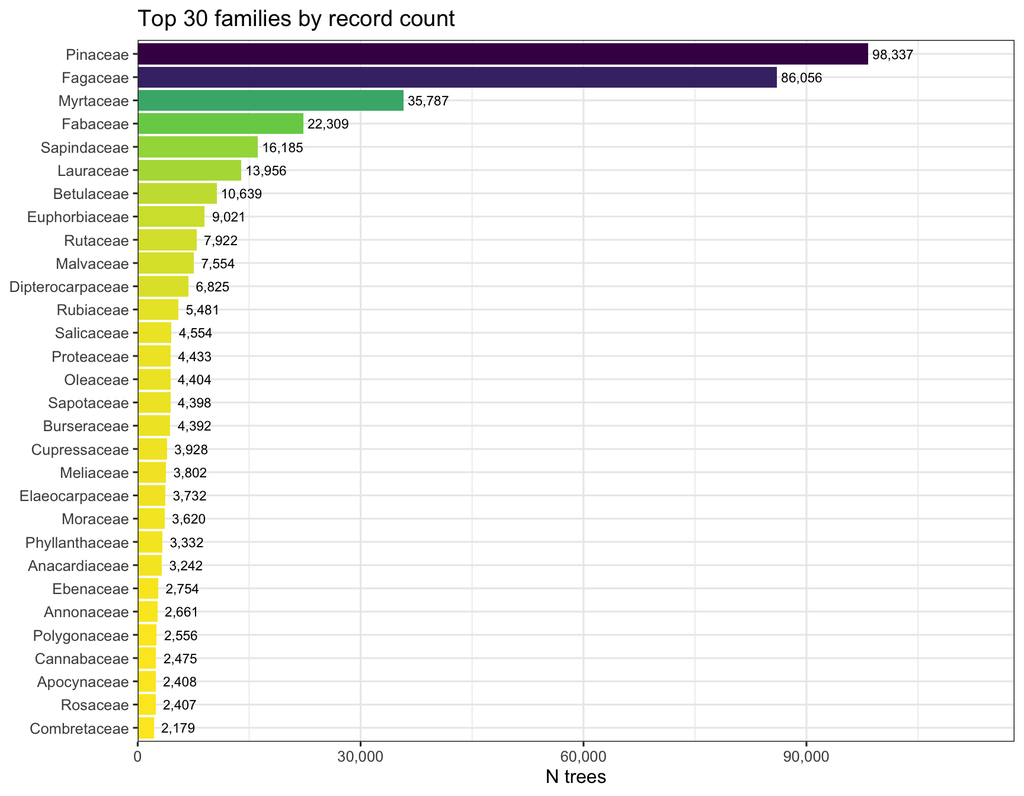

```r
tallo |>
  filter(!is.na(family)) |>
  count(family, sort = TRUE) |>
  head(30) |>
  ggplot(aes(x = reorder(family, n), y = n, fill = n)) +
  geom_col(show.legend = FALSE) +
  geom_text(aes(label = format(n, big.mark=",")), hjust = -0.1, size = 3) +
  coord_flip() +
  scale_y_continuous(labels = comma, expand = expansion(mult = c(0, 0.2))) +
  scale_fill_viridis_c(direction = -1) +
  labs(x = NULL, y = "N trees", title = "Top 30 families by record count")
```

## 6.3 Top 30 species

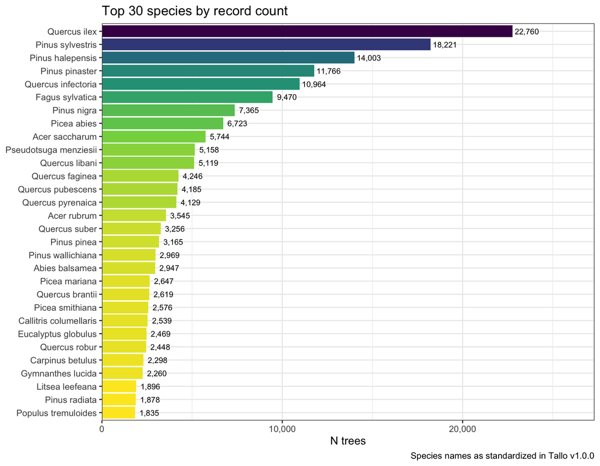

```r
tallo |>
  filter(!is.na(species)) |>
  count(species, sort = TRUE) |>
  head(30) |>
  ggplot(aes(x = reorder(species, n), y = n, fill = n)) +
  geom_col(show.legend = FALSE) +
  geom_text(aes(label = format(n, big.mark=",")), hjust = -0.1, size = 3) +
  coord_flip() +
  scale_y_continuous(labels = comma, expand = expansion(mult = c(0, 0.2))) +
  scale_fill_viridis_c(direction = -1) +
  labs(x = NULL, y = "N trees",
       title = "Top 30 species by record count",
       caption = "Species names as standardized in Tallo v1.0.0")
```

# 7 Size distributions

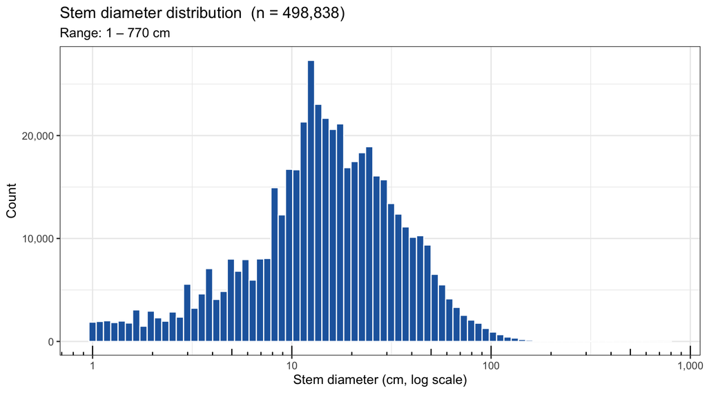

```r
tallo |> filter(!is.na(stem_diameter_cm), stem_diameter_cm > 0) |>
  ggplot(aes(x = stem_diameter_cm)) +
  geom_histogram(bins = 80, fill = "#2166ac", color = "white") +
  scale_x_log10(labels = comma) +
  scale_y_continuous(labels = comma) +
  annotation_logticks(sides = "b") +
  labs(x = "Stem diameter (cm, log scale)", y = "Count",
       title = paste0("Stem diameter distribution  (n = ",
                      format(sum(!is.na(tallo$stem_diameter_cm)), big.mark=","), ")"),
       subtitle = paste0("Range: ", round(min(tallo$stem_diameter_cm, na.rm=TRUE),1),
                         " – ", round(max(tallo$stem_diameter_cm, na.rm=TRUE),1), " cm"))
```

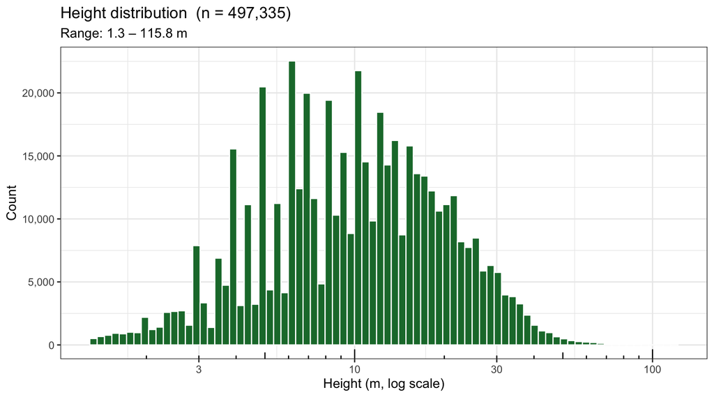

```r
tallo |> filter(!is.na(height_m), height_m > 0) |>
  ggplot(aes(x = height_m)) +
  geom_histogram(bins = 80, fill = "#1b7837", color = "white") +
  scale_x_log10(labels = comma) +
  scale_y_continuous(labels = comma) +
  annotation_logticks(sides = "b") +
  labs(x = "Height (m, log scale)", y = "Count",
       title = paste0("Height distribution  (n = ",
                      format(sum(!is.na(tallo$height_m)), big.mark=","), ")"),
       subtitle = paste0("Range: ", round(min(tallo$height_m, na.rm=TRUE),1),
                         " – ", round(max(tallo$height_m, na.rm=TRUE),1), " m"))
```

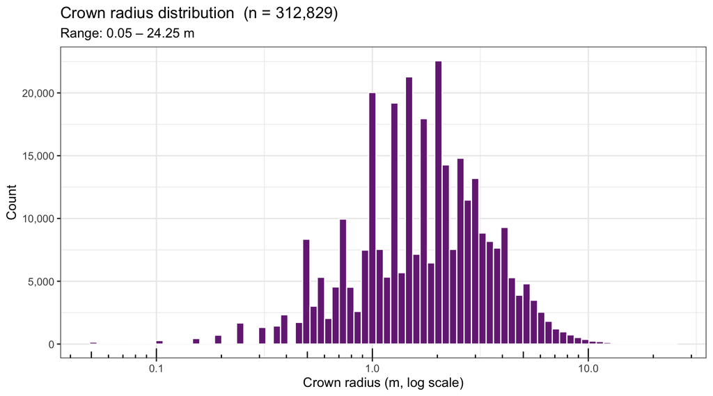

```r
tallo |> filter(!is.na(crown_radius_m), crown_radius_m > 0) |>
  ggplot(aes(x = crown_radius_m)) +
  geom_histogram(bins = 80, fill = "#762a83", color = "white") +
  scale_x_log10(labels = comma) +
  scale_y_continuous(labels = comma) +
  annotation_logticks(sides = "b") +
  labs(x = "Crown radius (m, log scale)", y = "Count",
       title = paste0("Crown radius distribution  (n = ",
                      format(sum(!is.na(tallo$crown_radius_m)), big.mark=","), ")"),
       subtitle = paste0("Range: ", round(min(tallo$crown_radius_m, na.rm=TRUE),2),
                         " – ", round(max(tallo$crown_radius_m, na.rm=TRUE),2), " m"))
```

# 8 Scaling relationships

All regressions below are **exploratory OLS on log10-transformed data** using a 10% random sample for speed. Use SMA (`smatr`) for formal allometric inference.

```r
set.seed(123)
sub <- tallo |>
  filter(!is.na(stem_diameter_cm), stem_diameter_cm > 0,
         !is.na(height_m), height_m > 0) |>
  sample_frac(0.10)
```

## 8.1 Height vs. stem diameter

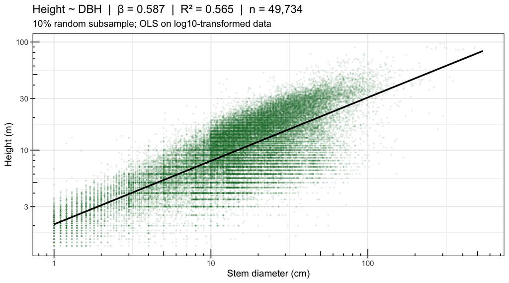

```r
lm1 <- lm(log10(height_m) ~ log10(stem_diameter_cm), data = sub)
b1 <- round(coef(lm1)[2], 3)
r2 <- round(summary(lm1)$r.squared, 3)
n1 <- nrow(sub)

ggplot(sub, aes(x = stem_diameter_cm, y = height_m)) +
  geom_point(alpha = 0.08, size = 0.5, color = "#1b7837") +
  geom_smooth(method = "lm", color = "black", linewidth = 1) +
  scale_x_log10(labels = comma) + scale_y_log10(labels = comma) +
  annotation_logticks() +
  labs(x = "Stem diameter (cm)", y = "Height (m)",
       title = paste0("Height ~ DBH  |  β = ", b1, "  |  R² = ", r2,
                      "  |  n = ", format(n1, big.mark=",")),
       subtitle = "10% random subsample; OLS on log10-transformed data")
```

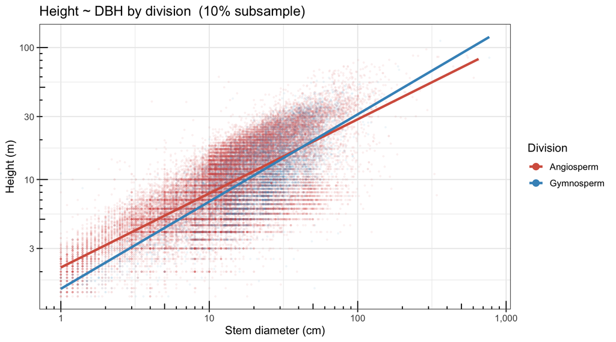

```r
sub_div <- tallo |>
  filter(!is.na(stem_diameter_cm), stem_diameter_cm > 0,
         !is.na(height_m), height_m > 0, !is.na(division)) |>
  sample_frac(0.10)

ggplot(sub_div, aes(x = stem_diameter_cm, y = height_m, color = division)) +
  geom_point(alpha = 0.06, size = 0.5) +
  geom_smooth(method = "lm", linewidth = 1.2, se = FALSE) +
  scale_x_log10(labels = comma) + scale_y_log10(labels = comma) +
  annotation_logticks() +
  scale_color_manual(values = c(Angiosperm = "#d6604d", Gymnosperm = "#4393c3")) +
  guides(color = guide_legend(override.aes = list(alpha=1, size=3))) +
  labs(x = "Stem diameter (cm)", y = "Height (m)",
       title = "Height ~ DBH by division  (10% subsample)",
       color = "Division")
```